# Prediction Assignment

Sebastian Ang

7/1/2020

## Data Exploration

Import data. We mix the final testing data together with the training data here, because we will do PCA analysis, and since we have the data beforehand it is easier to perform PCA together to ensure the variables are reduced to the same dimensions.

Note that there are a lot of almost empty columns, and some containing NA values. We first clean the data for any columns that exhibit sporadic and incomplete data, or empty columns. We also remove the predicted variable classe from this master dataframe

Note that after cleaning, we are still left with a huge number of 59 variables, as seen below.

```r
build <- read.csv("data\\pml-training.csv")
validation <- read.csv("data\\pml-testing.csv")
masterdata <- plyr::rbind.fill(build,validation)

masterdata <- masterdata[,colSums(is.na(masterdata)) < 1]
masterdata <- masterdata[,colSums(masterdata=="")<1]
names(masterdata)
```

```
##  [1] "X"                    "user_name"            "raw_timestamp_part_1"
##  [4] "raw_timestamp_part_2" "cvtd_timestamp"       "new_window"
##  [7] "num_window"           "roll_belt"            "pitch_belt"
## [10] "yaw_belt"             "total_accel_belt"     "gyros_belt_x"
## [13] "gyros_belt_y"         "gyros_belt_z"         "accel_belt_x"
## [16] "accel_belt_y"         "accel_belt_z"         "magnet_belt_x"
## [19] "magnet_belt_y"        "magnet_belt_z"        "roll_arm"
## [22] "pitch_arm"            "yaw_arm"              "total_accel_arm"
## [25] "gyros_arm_x"          "gyros_arm_y"          "gyros_arm_z"
## [28] "accel_arm_x"          "accel_arm_y"          "accel_arm_z"
## [31] "magnet_arm_x"         "magnet_arm_y"         "magnet_arm_z"
## [34] "roll_dumbbell"        "pitch_dumbbell"       "yaw_dumbbell"
## [37] "total_accel_dumbbell" "gyros_dumbbell_x"     "gyros_dumbbell_y"
## [40] "gyros_dumbbell_z"     "accel_dumbbell_x"     "accel_dumbbell_y"
## [43] "accel_dumbbell_z"     "magnet_dumbbell_x"    "magnet_dumbbell_y"
## [46] "magnet_dumbbell_z"    "roll_forearm"         "pitch_forearm"
## [49] "yaw_forearm"          "total_accel_forearm"  "gyros_forearm_x"
## [52] "gyros_forearm_y"      "gyros_forearm_z"      "accel_forearm_x"
## [55] "accel_forearm_y"      "accel_forearm_z"      "magnet_forearm_x"
## [58] "magnet_forearm_y"     "magnet_forearm_z"
```

We find that the relevant data starts from columns 8 onwards.

```r
masterdata <- masterdata[,8:59]
```

We still have 52 variables, hence we perform pre-processing by conducting principal-components analysis PCA (previously we have made sure to ignore the predicted variable “classe”), to try and reduce the dimensionality of the dataset. PCA analysis shows us that by including up to PC25, we are able to capture 95% of the dataset’s variability!

```r
masterdataProcessed <- prcomp(masterdata[,1:52], center = TRUE, scale = TRUE)
summary(masterdataProcessed)
```

```
## Importance of components:
##                           PC1    PC2     PC3     PC4     PC5     PC6     PC7
## Standard deviation     2.8911 2.8466 2.16261 2.03203 1.91116 1.73278 1.49679
## Proportion of Variance 0.1607 0.1558 0.08994 0.07941 0.07024 0.05774 0.04308
## Cumulative Proportion  0.1607 0.3166 0.40651 0.48591 0.55615 0.61389 0.65698
##                            PC8     PC9    PC10    PC11    PC12    PC13    PC14
## Standard deviation     1.43941 1.31036 1.22857 1.17684 1.06248 0.99335 0.94354
## Proportion of Variance 0.03984 0.03302 0.02903 0.02663 0.02171 0.01898 0.01712
## Cumulative Proportion  0.69682 0.72984 0.75887 0.78550 0.80721 0.82619 0.84331
##                           PC15    PC16    PC17    PC18    PC19    PC20    PC21
## Standard deviation     0.91440 0.88837 0.82329 0.78088 0.72971 0.69633 0.65254
## Proportion of Variance 0.01608 0.01518 0.01303 0.01173 0.01024 0.00932 0.00819
## Cumulative Proportion  0.85939 0.87457 0.88760 0.89933 0.90957 0.91889 0.92708
##                           PC22    PC23    PC24    PC25    PC26    PC27    PC28
## Standard deviation     0.63119 0.61859 0.58243 0.55471 0.54125 0.50591 0.48623
## Proportion of Variance 0.00766 0.00736 0.00652 0.00592 0.00563 0.00492 0.00455
## Cumulative Proportion  0.93474 0.94210 0.94862 0.95454 0.96017 0.96510 0.96964
##                           PC29    PC30    PC31    PC32    PC33    PC34    PC35
## Standard deviation     0.45108 0.42404 0.41255 0.36281 0.34900 0.33545 0.30318
## Proportion of Variance 0.00391 0.00346 0.00327 0.00253 0.00234 0.00216 0.00177
## Cumulative Proportion  0.97356 0.97701 0.98029 0.98282 0.98516 0.98732 0.98909
##                           PC36    PC37    PC38    PC39    PC40    PC41    PC42
## Standard deviation     0.28232 0.25333 0.23777 0.23487 0.20197 0.19523 0.18839
## Proportion of Variance 0.00153 0.00123 0.00109 0.00106 0.00078 0.00073 0.00068
## Cumulative Proportion  0.99063 0.99186 0.99295 0.99401 0.99479 0.99552 0.99621
##                           PC43    PC44    PC45    PC46    PC47   PC48    PC49
## Standard deviation     0.18366 0.17945 0.16946 0.16384 0.14717 0.1435 0.11607
## Proportion of Variance 0.00065 0.00062 0.00055 0.00052 0.00042 0.0004 0.00026
## Cumulative Proportion  0.99686 0.99748 0.99803 0.99854 0.99896 0.9994 0.99962
##                           PC50    PC51    PC52
## Standard deviation     0.10899 0.07722 0.04634
## Proportion of Variance 0.00023 0.00011 0.00004
## Cumulative Proportion  0.99984 0.99996 1.00000
```

However we shall attempt to further reduce the number of variables involved. The PCA plot tells us that eigenvalue = 1 when we include up to the 13th PC.

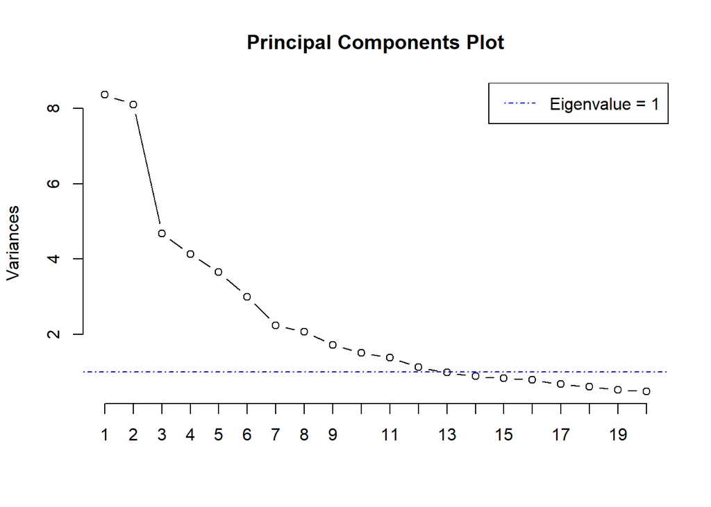

```r
plot(masterdataProcessed, type = "l", npcs = 20, main = "Principal Components Plot")
abline(h = 1, col = "blue", lty = 10)
legend("topright", legend = c("Eigenvalue = 1"), col = c("blue"), lty = 10)
```

We rebuild our dataset by stitching the predicted variable “classe” with the reduced principal components, making sure to only take the training data. The components stitched will include up to only the 13th PC. Then we then further divide the pml-training data into a training_training and training_testing set.

We also take this opportunity to recreate our testing set for the final assignment

```r
masterdataProcessed <- data.frame(masterdataProcessed$x)
totalRows <- nrow(masterdataProcessed)-20

buildPCA <- masterdataProcessed[1:totalRows,1:13]
training <- data.frame(buildPCA, classe = as.factor(build$classe))

inTrain <- caret::createDataPartition(y = training$classe, p = .7, list = FALSE)
training_training <- training[inTrain,]
training_testing <- training[-inTrain,]

dim(training_training); dim(training_testing)
```

```
## [1] 13737    14
```

```
## [1] 5885   14
```

```r
testing <- masterdataProcessed[totalRows:nrow(masterdataProcessed),1:13]
```

## Building Machine Learning model

Here we use Random Forest to conduct machine learning, as we have more than two classes, and Random Forest works great as a classifier algorithm.

By default the train function in the caret package chooses the cross validation by itself. We can choose to take this one step further and tune the parameters ourselves. We define the training method to be used. We set 5-folds cross-validation as the preferred method.

We call this random forest model “mdl”

```r
control <- caret::trainControl(method="cv", number=5, verbose = FALSE)
mdl <- caret::train(classe ~ . ,method = "rf", data = training_training, trControl = control, ntree=250)
```

We extend the model to do a prediction test on the training_testing data.

We then tabulate the prediction results against the actual class of the underlying testing data, and calculate the prediction accuracy of the results. Note that it appears to be quite accurate with accuracy = 0.96

```r
pred1 <- predict(mdl, training_testing)
table(pred1, training_testing$classe)
```

```
##
## pred1    A    B    C    D    E
##     A 1642   28    5    2    0
##     B    6 1085   21    5    6
##     C   14   15  984   48    5
##     D   11    5   15  905   12
##     E    1    6    1    4 1059
```

```r
sum(diag(table(pred1, training_testing$classe)))/sum(table(pred1, training_testing$classe))
```

```
## [1] 0.9643161
```

Once again we see the predictive potential of the RF model. We take a closer look at the model output conditions. The resampling results show that the model seems to exhibit similar accuracy as calculated

```r
mdl
```

```
## Random Forest
##
## 13737 samples
##    13 predictor
##     5 classes: 'A', 'B', 'C', 'D', 'E'
##
## No pre-processing
## Resampling: Cross-Validated (5 fold)
## Summary of sample sizes: 10989, 10989, 10990, 10990, 10990
## Resampling results across tuning parameters:
##
##   mtry  Accuracy   Kappa
##    2    0.9537743  0.9415252
##    7    0.9480966  0.9343477
##   13    0.9410353  0.9254206
##
## Accuracy was used to select the optimal model using the largest value.
## The final value used for the model was mtry = 2.
```